# Analyse des données pour Amélie Cassaz

Nicolas Bressoud

novembre 2020

# 1 Contexte et mesures

Ce rapport analyse l’évolution des scores dans deux groupes (expérimental / contrôle) impliquant au total 6 classes. Les classes A, C et E sont des classes expérimentales. Les classes B, D et F sont des classes contrôle.

Le but de l’expérience visait à observer si la mise en oeuvre de conseils de classe favorisait l’inhibition comportementale des élèves de groupe expérimental.

Toutes les classes ont eu un pré-test et un post-test durant lesquels les élèves ont répondu, à chacune des 2 passations, 25 fois à un exercice d’inhibition comportementale (test HTKS). L’expérimentatrice a scoré chaque exercice de la manière suivante :

- 0 : l’enfant n’a pas réussi ou l’enfant a cherché des indices chez l’expérimentatrice
- 1 : l’enfant a réussi avec une hésitation modérée (hésitation dans les gestes, traits du visage), tout en étant concentré sur la tâche
- 2 : l’enfant a réussi avec aisance tout en étant concentré

# 2 Statistiques descriptives

Les 2 tableaux ci-dessous synthétisent les données descriptives :

(#tab:sample_final1)résumé des données sur les participant·es

| grp | clas | sex | n | mean_age |
| --- | --- | --- | --- | --- |
| Contrôle | B | filles | 26 | 7.54 |
| Contrôle | B | garçons | 10 | 7.60 |
| Contrôle | D | filles | 4 | 7.50 |
| Contrôle | D | garçons | 16 | 7.75 |
| Contrôle | F | filles | 10 | 7.90 |
| Contrôle | F | garçons | 10 | 7.60 |
| Expérimental | A | filles | 12 | 7.50 |
| Expérimental | A | garçons | 22 | 7.55 |
| Expérimental | C | filles | 12 | 7.58 |
| Expérimental | C | garçons | 18 | 7.56 |
| Expérimental | E | filles | 16 | 7.56 |
| Expérimental | E | garçons | 6 | 8.00 |

(#tab:sample_final2)résumé des scores de l’échantillon aux temps 1 et 2

| tps | grp | n | mean_sco | sd_sco |
| --- | --- | --- | --- | --- |
| 1 | Contrôle | 38 | 1.37 | 0.35 |
| 1 | Expérimental | 43 | 1.42 | 0.33 |
| 2 | Contrôle | 38 | 1.46 | 0.23 |
| 2 | Expérimental | 43 | 1.70 | 0.23 |

# 3 Statistiques inférentielles

Nous avons conduit une ANOVA à plan factoriel construite ainsi :

- variable intersujet : le groupe (contrôle ou expérimental)
- variable intrasujet : le temps (avant ou après l’expérimentation)

(#tab:sample_final2)Résultats de l’ANOVA

| term | df | sumsq | meansq | statistic | p.value |
| --- | --- | --- | --- | --- | --- |
| tps | 1 | 1.53 | 1.53 | 18.04 | 0.00 |
| grp | 1 | 0.88 | 0.88 | 10.32 | 0.00 |
| tps:grp | 1 | 0.38 | 0.38 | 4.47 | 0.04 |
| Residuals | 158 | 13.43 | 0.08 | NA | NA |

Le calcul de $\eta ^{2}$ est réalisé avec la fonction `eta_sq` du package `sjstats`.

Le graph suivant donne une illustration des données :

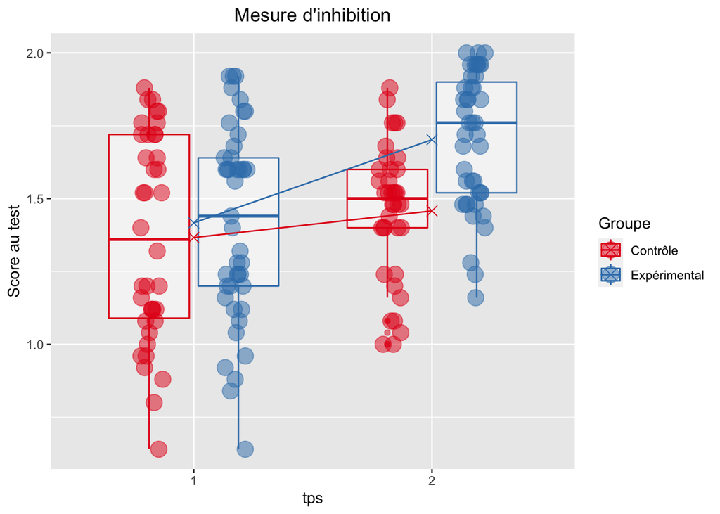

# 4 Interprétation et conclusion

L’analyse de variance a mis en évidence un effet significatif de l’interation entre le type de groupe (contrôle, expérimental) et le temps (avant, après) sur le score d’inhibition comportementale (*F*(1,158) = 4.47, *p* = .036). Cet effet est toutefois petit ($\eta ^{2}$ = 0.023).

Cet effet indique que les élèves du groupe expérimental ont une différence de score entre les deux temps de mesure significativement plus élevée ($\overline{m}$ = 1.42, sd = 0.33 ; $\overline{m}$ = 1.70 , s = 0.23) que les élèves du groupe contrôle ($\overline{m}$ = 1.37, sd = 0.35; $\overline{m}$ = 1.46, sd = 0.23).